# Data Visualization Part I: Exploratory Graphics

Crime Analytics (CJUS 6106)

## Visualizing Data

A fundamental component of any research project is visualizing your data. Most published research will have at least one or two data visualizations that show readers the distribution of some outcome or visualize the results of a statistical model.

Data visualization is also very helpful when you are beginning a research project and want to know what your data “look like.”

For example, if you are planning to run a linear regression model, it is important to know if the bivariate relationships in your data are approximately linear. If not, bivariate plots can point you toward the necessary variable transformations to alleviate the problem.

We generally refer to data visualizations like these as exploratory graphics. There’s no hypothesis we are testing at this point - we are just trying to get a grasp of how our data behave using visuals instead of just statistics.

### Why Are Exploratory Graphics Important?

Numbers won’t tell you the full story, that’s why. Anscombe’s Quartet is an excellent example for demonstrating this.

Let’s load the Anscombe data to see why (it comes with the “car” package, so you need to install that first if you have not already):

```r
data(anscombe)
```

Let’s look at a summary of this data frame to see how the statistics across the columns compare.

```r
summary(anscombe)
```

```
##        x1             x2             x3             x4           y1
##  Min.   : 4.0   Min.   : 4.0   Min.   : 4.0   Min.   : 8   Min.   : 4.260
##  1st Qu.: 6.5   1st Qu.: 6.5   1st Qu.: 6.5   1st Qu.: 8   1st Qu.: 6.315
##  Median : 9.0   Median : 9.0   Median : 9.0   Median : 8   Median : 7.580
##  Mean   : 9.0   Mean   : 9.0   Mean   : 9.0   Mean   : 9   Mean   : 7.501
##  3rd Qu.:11.5   3rd Qu.:11.5   3rd Qu.:11.5   3rd Qu.: 8   3rd Qu.: 8.570
##  Max.   :14.0   Max.   :14.0   Max.   :14.0   Max.   :19   Max.   :10.840
##        y2              y3              y4
##  Min.   :3.100   Min.   : 5.39   Min.   : 5.250
##  1st Qu.:6.695   1st Qu.: 6.25   1st Qu.: 6.170
##  Median :8.140   Median : 7.11   Median : 7.040
##  Mean   :7.501   Mean   : 7.50   Mean   : 7.501
##  3rd Qu.:8.950   3rd Qu.: 7.98   3rd Qu.: 8.190
##  Max.   :9.260   Max.   :12.74   Max.   :12.500
```

Values within the X (1 to 4) and Y (1 to 4) columns look pretty similar, right? If I were to regress each Y column on its respective X column (e.g., predict y1 using x1) I should see similar plots if I base my expectation on these statistics alone.

Let’s do that now to confirm this expectation:

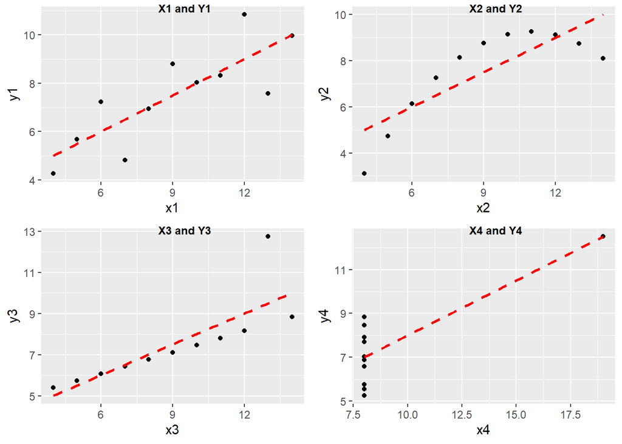

```r
library(ggplot2)
library(ggpubr)
anscombe1<-ggplot(anscombe, aes(x=x1, y=y1)) +
  geom_point() +
  geom_smooth(method="lm", linetype="dashed", color="red", se=FALSE)
anscombe2<-ggplot(anscombe, aes(x=x2, y=y2)) +
  geom_point() +
  geom_smooth(method="lm", linetype="dashed", color="red", se=FALSE)
anscombe3<-ggplot(anscombe, aes(x=x3, y=y3)) +
  geom_point() +
  geom_smooth(method="lm", linetype="dashed", color="red", se=FALSE)
anscombe4<-ggplot(anscombe, aes(x=x4, y=y4)) +
  geom_point() +
  geom_smooth(method="lm", linetype="dashed", color="red", se=FALSE)

anscombe_plot<- ggarrange(anscombe1, anscombe2, anscombe3, anscombe4,
                     labels=c("X1 and Y1", "X2 and Y2", "X3 and Y3",
                              "X4 and Y4"),
                     font.label=list(color="black", size=9),
                     hjust=-3,
                     ncol=2, nrow=2)
anscombe_plot
```

First, take a look at each best fit line - that line reflects the conditional expectations for the values of Y from a bivariate regression model. Each line has the **same** slope!

Even though they have the same slope, however, the plots can differ quite a lot. For example, compare the plot for X4 and Y4 to the others. It shares almost no similarities and yet, a regression model would tell us the relationship between X4 and Y4 is the same as between X3 and Y3, X2 and Y2, and X1 and Y1.

Hopefully, this example illustrates why visually inspecting your data is important. Numeric statistics can tell us a lot about the relationship between variables but those numbers can hide differences like we just saw.

### Qualities of a “Good” Exploratory Visualization

What makes a visualization “good” or “bad?” Here are a few general things I look for when I evaluate a research manuscript’s visualizations:

- Does the visualization fit the data types included?
  - That is, is the type of visualization proper for the way the variable or variables are measured?
- Is the visualization properly labeled?
  - Does the graph have a title? The axes? How about numeric labels along the axes?
  - E.g., if it’s a bar plot, do the bars have labels for their %, count, or mean?
- Are the axes properly scaled?
  - People can get tricksy with these - always inspect the scale of the axes. Are there jumps in the numbers? Are the axes magnified to a very small range?
- Are all lines, dots, or markers explained properly?
  - Is there a legend? Does it provide enough detail to interpret the figure?

These are just a few considerations that spring to mind. The general goal for a figure in any research project should be to convey its message in a way that nearly any reader could understand *just by looking at it*. If your figure requires lots of explanation for how it was put together, chances are you’ve done it wrong.

*Note: Some figures are complex and require some additional explanation, but these are rare and you are very unlikely to run into this situation for your research projects.*

### Exploratory Graphics - Where to Start?

It’s best to start with knowing what types of graphs work for the types of variables you have. This mostly has to do with whether movement along the X-axis is meaningful or not.

As an example, if I want to know the frequencies of different nominal categories in my data, I would use a bar graph. This is because the X-axis in a bar graph is not used to communicate fixed intervals between values.

By contrast, a bar graph is not useful for interval/ratio level variables because:

- Increases/decreases in X are meaningful and are fixed intervals
- There can be far too many values to include a bar for each and too few values for each bar

Here’s a short table of the types of graphs that work for variables at different levels of measurement:

| Plot type | **Nominal** | **Ordinal** | **Interval/Ratio** |
| --- | --- | --- | --- |
| Bar graph | X | X |  |
| Pie chart | X | X |  |
| Box plot |  |  | X |
| Scatter plot |  |  | X |
| Histogram |  |  | X |
| Line graph |  |  | X |
| Area graph |  |  | X |
| Dot plot |  |  | X |

You can clearly see that nominal/ordinal level variables have few plot types available. Also note that this is **not** an exhaustive list of all types of plots out there, just the more common ones.

Quick note - a boxplot requires an X and Y variable and while the X variable can be nominal/ordinal, the Y variable must be Interval/Ratio, which is why I indicate it can only be used with Interval/Ratio level data.

### How to Make Different Plot Types

There are a few different ways to make plots in R but we will focus specifically on a popular package called ggplot2. The “gg” stands for *Grammar of Graphics*.

Within this package are multiple different options for **geoms** or geometric objects. Along with setting your X and Y variables, these geom options will tell R which type of plot to create.

Some common geoms include:

- **geom_bar()**: Your old-fashioned bar plot
- **geom_point()**: This is your scatter plot
- **geom_histogram()**: I think this one is self-explanatory
- **geom_boxplot()**: The ever-useful boxplot
- **geom_line()**: This makes a line graph with connected points (just have to make sure R knows the order to connect the points!)

Within the parentheses for each of these you have access to multiple options that can control the look of the plot. For example, the linetype option for the geom_line() function allows you to change how the line is drawn (e.g., linetype=“dashed” will draw a dashed line). We will talk more about these options later.

### Quick Note - Can Plots Be Objects?

**Yes!** Plots can be stored as objects in R. What’s really cool is that you can store a plot and then add features to it later. I show some of this in action below.

## Creating Exploratory Plots in R

### Bar Plots

We’ll start with the most simple plot type - bar plots. For this, we need nominal or ordinal level data (and remember that we can make nominal/ordinal level variables from interval/ratio level variables).

For the purposes of the examples in this lecture I will use a data set that’s featured in just about every single statistics program I have ever used. The data set is called “mtcars” and it’s a compilation of design features and performance for 32 cars included in a Motor Trend magazine from 1974.

```r
data(mtcars)
```

If you’d like to see a description of these data you can type ?mtcars into the console pane and a help page will appear with said description.

Okay, with that out of the way, let’s make a simple bar plot that shows the distribution of transmission types for these vehicles.

```r
mtcars$am[mtcars$am==0] <- "Automatic"
mtcars$am[mtcars$am==1] <- "Manual"
mtcars$am <- as.factor(mtcars$am)
```

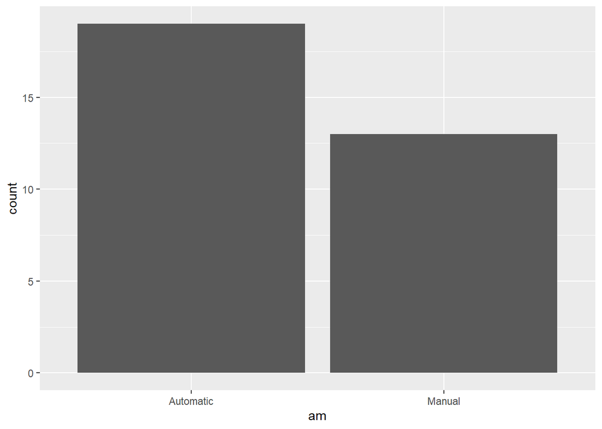

```r
bar_plot <- ggplot(mtcars, aes(x=am))
bar_plot <- bar_plot + geom_bar(stat="count")
bar_plot
```

That’s a good start, but there are some messy parts to this.

- There’s no title for the plot
- The axis titles are just the variable names
- It’s hard to tell exactly what value the height of each bar represents

We’re going to fix all of these issues by adding some additional options to this plot object.

First, we need a snappy title.

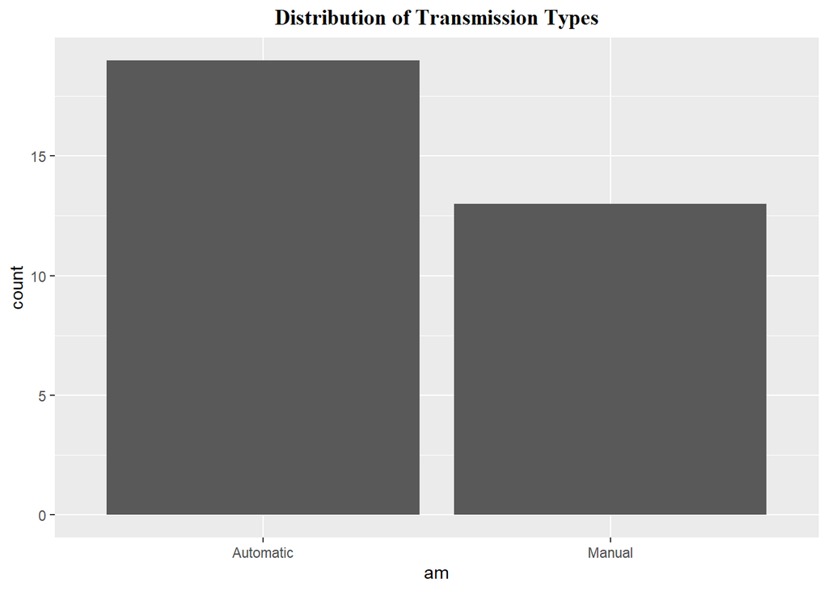

```r
bar_plot <- bar_plot +
  ggtitle("Distribution of Transmission Types") +
  theme(plot.title=element_text(hjust=0.5,
                                face="bold", family="serif"))
bar_plot
```

Okay, we have a plot title. Now we need titles for each axis.

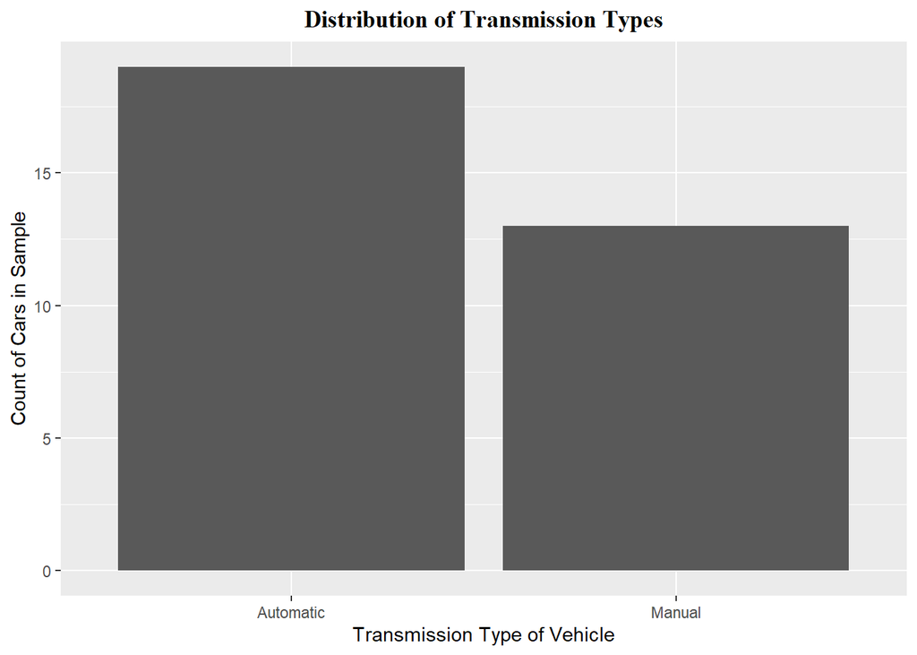

```r
bar_plot <- bar_plot +
  xlab("Transmission Type of Vehicle") +
  ylab("Count of Cars in Sample")
bar_plot
```

Perfect. Now we need a clearer indication of what exact value is represented by the height of the bar.

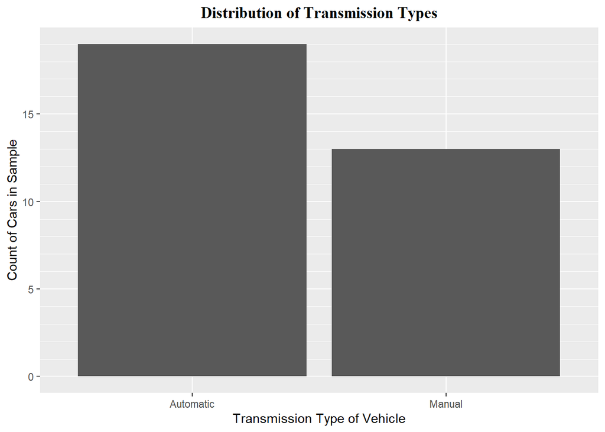

```r
bar_plot <- bar_plot +
  scale_y_continuous(minor_breaks = seq(0, 20, by=1))
bar_plot
```

This gets us partway there, but what if we could create labels that appear within the bars that provide the specific count?

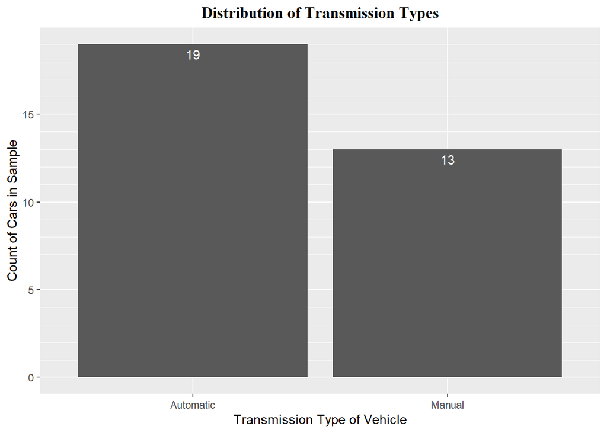

```r
bar_plot <- bar_plot + geom_text(stat="count",
                                 aes(label=after_stat(count)),
                                 vjust=1.5, color="white")
bar_plot
```

Okay, I’m happy with this now because I have covered all of the basic elements of making a good plot and the visualization should make clear to just about anyone what this means.

One quick note before we move on, though. In the code chunks above I incrementally add features to the plot but this is to show you how it changes.

In practice, I would combine all of this code into one function instead of several. Here’s what that would look like:

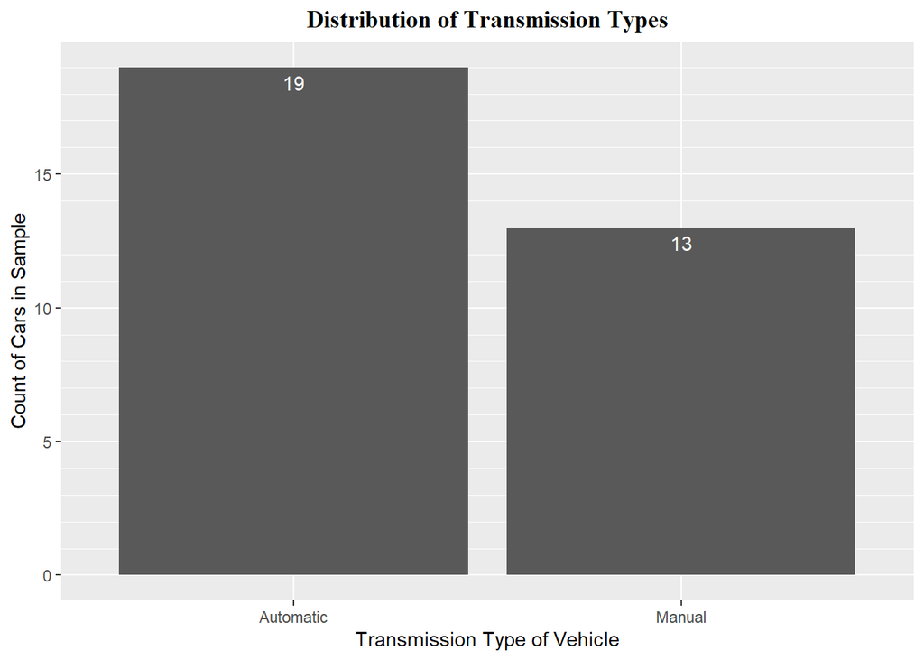

```r
bar_plot2 <- ggplot(mtcars, aes(x=am)) +
  geom_bar(stat="count") +
  ggtitle("Distribution of Transmission Types") +
  theme(plot.title=element_text(hjust=0.5,
                                face="bold", family="serif")) +
  xlab("Transmission Type of Vehicle") +
  ylab("Count of Cars in Sample") +
  scale_y_continuous(minor_breaks = seq(0, 20, by=1)) +
  geom_text(stat="count", aes(label=after_stat(count)),
                              vjust=1.5, color="white")
bar_plot2
```

#### Adding a Second Variable

I could add a second variable to this simple bar plot to visualize a joint distribution between transmission type and the number of cylinders the car’s engine has. I can accomplish this using the fill= option in the first ggplot() function, like so:

```r
mtcars$cyl <- as.factor(mtcars$cyl)
```

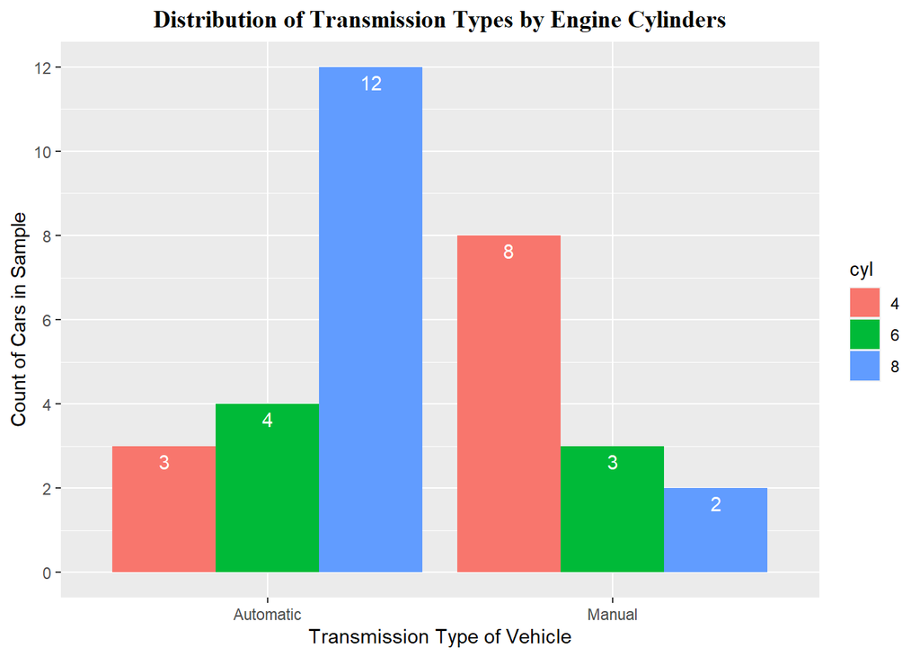

```r
bar_plot3 <- ggplot(mtcars, aes(x=am, fill=cyl)) +
  geom_bar(position="dodge", stat="count") +
  ggtitle("Distribution of Transmission Types by Engine Cylinders") +
  theme(plot.title=element_text(hjust=0.5,
                                face="bold", family="serif")) +
  xlab("Transmission Type of Vehicle") +
  ylab("Count of Cars in Sample") +
  scale_y_continuous(breaks = seq(0, 12, by=2), minor_breaks = seq(0, 13, by=1)) +
  geom_text(stat="count", aes(label=after_stat(count)),
                              vjust=1.5, color="white",
            position=position_dodge(0.9))
bar_plot3
```

Nifty.